## 計量地理學及實習 期中考前實習演練

#### 完整答案 助教 杜承軒 2018.10.24

> > 假設每個醫院可以服務所在鄉鎮以及最近3個鄉鎮 (用鄉鎮中心點距離判斷)，計算每個醫院的服務人數。  
> > ＊初步環境建置與讀取檔案

> ```r
> library(GISTools);library(rgdal);library(spatstat);library(plotrix);library(magrittr);library(sp);library(dplyr)
> setwd("D:/1071QG/QG1026/data1026")
> TW.shp=readOGR(dsn = ".", layer = "Taiwan", encoding="unicode",verbose = F)
> HP=readOGR(dsn = ".", layer = "Hospital", encoding="unicode",verbose = F)
> old.df=read.csv("Taiwan_oldratio.csv")
> TW=spTransform(TW.shp,HP@proj4string)
> ```

> > 1. 假設每個醫院可以服務所在鄉鎮以及最近3個鄉鎮 (用鄉鎮中心點距離判斷)，計算每個醫院的服務人數。

> 計算所在鄉鎮的人口：here.pop。

> ```r
> HP.TW.dist=gContains(TW,HP,byid=T)
> id=apply(HP.TW.dist,1,which)
> here.pop=TW$Population[id]
> ```

> 將所在鄉鎮排出，找出前三近鄉鎮，加總人口至near.pop。

> ```r
> TW2=gCentroid(TW,byid=T)
> HP.TW2.dist=gDistance(TW2,HP,byid=T)
> for(i in 1:length(HP)) HP.TW2.dist[i,id[i]]=Inf
> Min3=function(x) TW$Population[order(x)[1:3]]%>%sum
> near.pop=apply(HP.TW2.dist,1,Min3)
> ```

> 加總hear.pop與near.pop即可。

> ```r
> HP$pop=here.pop+near.pop
> HP@data[1:10,c(1,4)]
> ```

> ```
> ##                                                NAME     pop
> ## 1                              中山醫學大學附設醫院  417088
> ## 2                              中國醫藥大學附設醫院  357447
> ## 3                  佛教慈濟醫療財團法人台北慈濟醫院 1216144
> ## 4                          奇美醫療財團法人奇美醫院  629352
> ## 5                  長庚醫療財團法人林口長庚紀念醫院  729724
> ## 6                  長庚醫療財團法人高雄長庚紀念醫院  921301
> ## 7                    屏基醫療財團法人屏東基督教醫院  267780
> ## 8          財團法人私立高雄醫學大學附設中和紀念醫院  603839
> ## 9  台灣基督長老教會馬偕醫療財團法人新竹馬偕紀念醫院  535079
> ## 10     台灣基督長老教會馬偕醫療財團法人馬偕紀念醫院  735330
> ```

> > 補充：視為最鄰近的四個鄉鎮加總人口。

> ```r
> Min4=function(x) TW$Population[order(x)[1:4]]%>%sum
> HP$pop=apply(HP.TW2.dist,1,Min4)
> HP@data[1:10,c(1,4)]
> ```

> ```
> ##                                                NAME     pop
> ## 1                              中山醫學大學附設醫院  368480
> ## 2                              中國醫藥大學附設醫院  330104
> ## 3                  佛教慈濟醫療財團法人台北慈濟醫院 1230107
> ## 4                          奇美醫療財團法人奇美醫院  465599
> ## 5                  長庚醫療財團法人林口長庚紀念醫院  669981
> ## 6                  長庚醫療財團法人高雄長庚紀念醫院  958560
> ## 7                    屏基醫療財團法人屏東基督教醫院  107104
> ## 8          財團法人私立高雄醫學大學附設中和紀念醫院  391887
> ## 9  台灣基督長老教會馬偕醫療財團法人新竹馬偕紀念醫院  404628
> ## 10     台灣基督長老教會馬偕醫療財團法人馬偕紀念醫院  894159
> ```

> > 2. “老年人口比例”是評估地方人口老化常用的指標，請將老年人口資料整併是 Taiwan 的圖層，並用標準差的間距，繪製該指標的面量圖 (choropleth map)。

> ```r
> TW@data=left_join(TW@data,old.df)
> ```

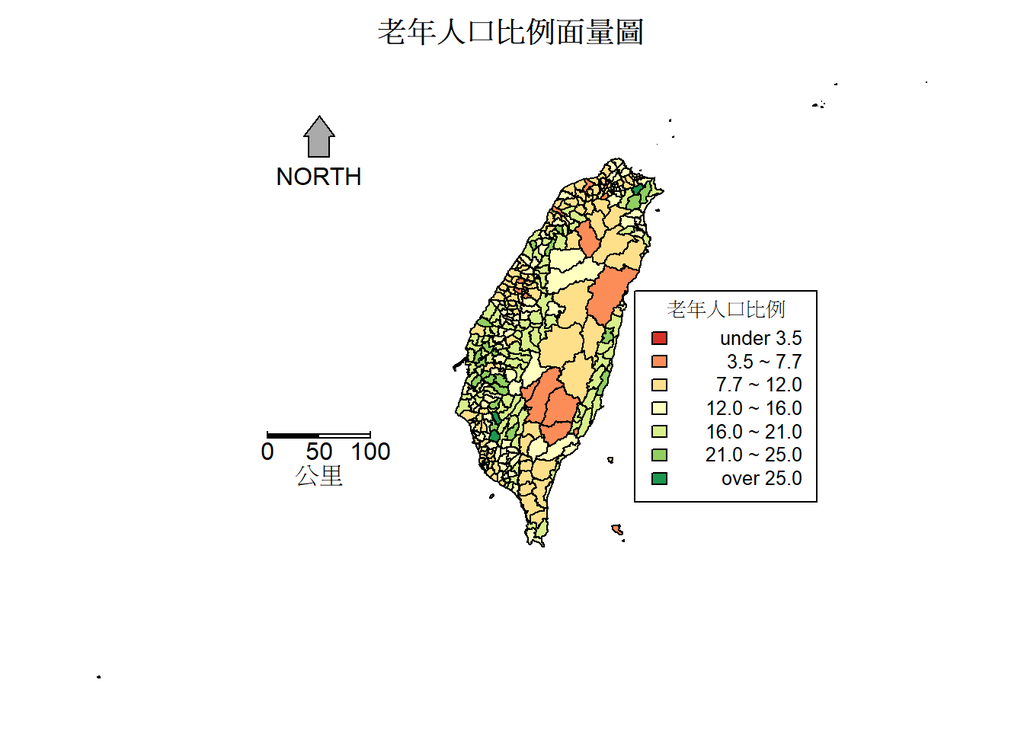

> ```r
> par(mar=c(1,1,2,1))
> old.shades = auto.shading(TW@data$Oldratio, n=7, cols=brewer.pal(7,"RdYlGn"), cutter=sdCuts)
> choropleth(TW,TW$Oldratio,shading=old.shades)
> title("老年人口比例面量圖")
> choro.legend(324000,2670000,old.shades,between = "~",fmt="%.1f",cex=0.8,title='老年人口比例')
> map.scale(17770,2528047,100000, "公里",2,50)
> north.arrow(17770,2800000,10000,col= '#AAAAAA')
> ```

> > 3. 繪製Box plot來呈現不同鄉鎮型態(都市 vs. 鄉村)的人口密度分布。

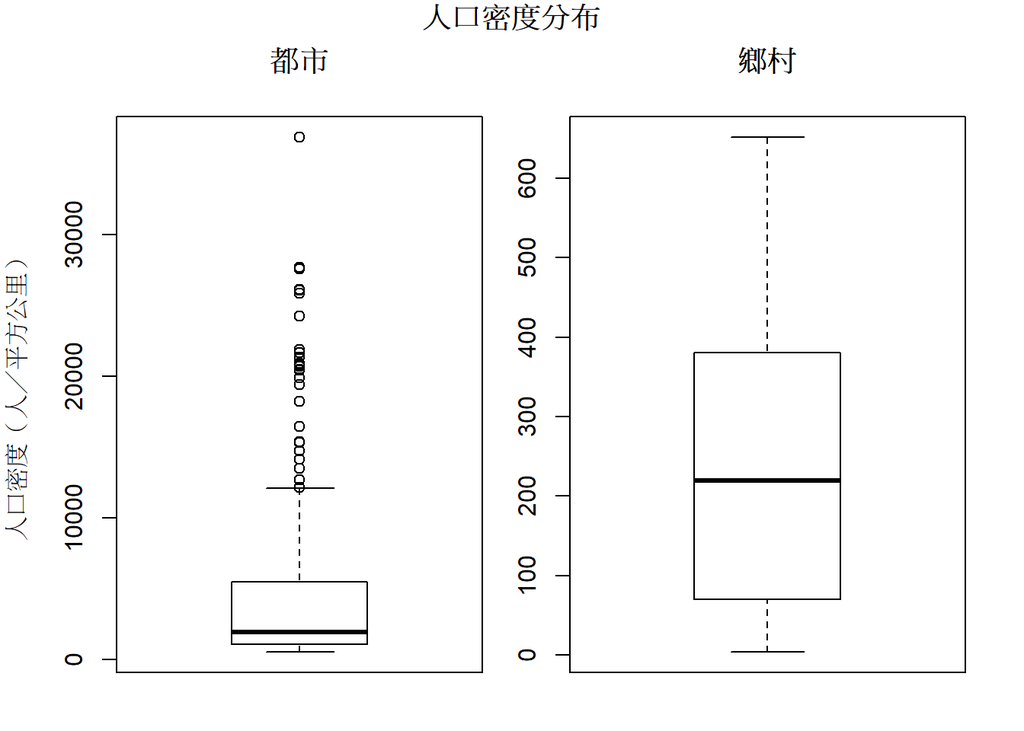

> ```r
> density=TW@data$Population/TW@data$Area*10^6
> urban=density[TW@data$area_level=="都市"]
> rural=density[TW@data$area_level=="鄉村"]
> par(mfrow = c(1,2))
> par(mar=c(2,4,4,1));boxplot(urban, main = "都市",ylab="人口密度（人／平方公里）")
> par(mar=c(2,2,4,2));boxplot(rural, main = "鄉村")
> par(mfrow = c(1,1));par(mar=c(2,2,1,2))
> title("人口密度分布")
> ```

> > 4. 呈上題，利用假設檢定分析不同鄉鎮型態(都市 vs. 鄉村)的平均收入，是否有顯著差異。

> $H_{0}:\mu_{urban}=μ_{rural}$ 虛無假設：都市與鄉村的平均收入無顯著差異  
> $H_{a}:\mu_{urban}\neqμ_{rural}$ 對立假設：都市與鄉村的平均收入有顯著差異

> ```r
> urban_income=TW$Income[TW@data$area_level=="都市"]
> rural_income=TW$Income[TW@data$area_level=="鄉村"]
>
> res=t.test(urban_income,rural_income)
> sprintf("t值為%.2f，p.value為%.2e。",res$statistic, res$p.value) #格式化輸出，可以用paste/print/cast就好。
> ```

> ```
> ## [1] "t值為10.98，p.value為8.72e-23。"
> ```

> 透過t檢定，在顯著水準α=0.01下，p value<α，拒絕虛無假設，代表都市與鄉村的平均收入有顯著差異。